# Final Project

Jiaxuan Sun

2022-11-29

## Introduction

The purpose of this project is to generate a model that will predict the rent for different Houses/Apartments/Flats.

### Context

In India, housing options range from the former Maharajahs’ palaces to contemporary apartment buildings in major cities to modest huts in remote areas. The housing market in India has expanded significantly as wages have increased. According to the Human Rights Measurement Initiative, India is meeting 60.9% of the right to housing at its current income level.

An agreement where a fee is paid for the temporary use of a good, service, or property owned by another is known as renting, sometimes known as hiring or letting. In a gross lease, the tenant makes a single monthly payment while the landlord covers all normal maintenance costs. The sharing economy can be applied to renting.

Let’s look at an example of India apartments.

[video not shown]

### Usefulness of this model

Using this model, we could better price for different states of houses/apartments/flats, which would improve the working efficiency of agents and lead to faster deal between owners and tenants.

## Loading Data and Packages

In this Data set, we have information on almost 4700+ Houses/Apartments/Flats Available for Rent with different parameters like BHK, Rent, Size, No. of Floors, Area Type, Area Locality, City, Furnishing Status, Type of Tenant Preferred, No. of Bathrooms, Point of Contact.

- **BHK**: Number of Bedrooms, Hall, Kitchen.
- **Rent**: Rent of the Houses/Apartments/Flats.
- **Size**: Size of the Houses/Apartments/Flats in Square Feet.
- **Floor**: Houses/Apartments/Flats situated in which Floor and Total Number of Floors (Example: Ground out of 2, 3 out of 5, etc.)
- **Area Type**: Size of the Houses/Apartments/Flats calculated on either Super Area or Carpet Area or Build Area.
- **Area Locality**: Locality of the Houses/Apartments/Flats.
- **City**: City where the Houses/Apartments/Flats are Located.
- **Furnishing Status**: Furnishing Status of the Houses/Apartments/Flats, either it is Furnished or Semi-Furnished or Unfurnished.
- **Tenant Preferred**: Type of Tenant Preferred by the Owner or Agent.
- **Bathroom**: Number of Bathrooms.
- **Point of Contact**: Whom should you contact for more information regarding the Houses/Apartments/Flats. As we can see, the *Rent* variable is our outcome, and the other 10 variables are our predictors.

```r
#load packages
library(tidymodels)
library(tidyverse)
library(corrplot)
library(rpart.plot)
library(janitor)
library(randomForest)
library(xgboost)
library(ranger)
library(discrim)
library(poissonreg)
library(corrr)
library(ggcorrplot)
library(kknn)
library(vip)
tidymodels_prefer()

#load data
rent_data = read.csv("House_Rent_Dataset.csv")
```

## Exploratary Data Analysis

```r
summary(rent_data)
```

```
##   Posted.On              BHK             Rent              Size
##  Length:4746        Min.   :1.000   Min.   :   1200   Min.   :  10.0
##  Class :character   1st Qu.:2.000   1st Qu.:  10000   1st Qu.: 550.0
##  Mode  :character   Median :2.000   Median :  16000   Median : 850.0
##                     Mean   :2.084   Mean   :  34993   Mean   : 967.5
##                     3rd Qu.:3.000   3rd Qu.:  33000   3rd Qu.:1200.0
##                     Max.   :6.000   Max.   :3500000   Max.   :8000.0
##     Floor            Area.Type         Area.Locality          City
##  Length:4746        Length:4746        Length:4746        Length:4746
##  Class :character   Class :character   Class :character   Class :character
##  Mode  :character   Mode  :character   Mode  :character   Mode  :character
##
##
##
##  Furnishing.Status  Tenant.Preferred      Bathroom      Point.of.Contact
##  Length:4746        Length:4746        Min.   : 1.000   Length:4746
##  Class :character   Class :character   1st Qu.: 1.000   Class :character
##  Mode  :character   Mode  :character   Median : 2.000   Mode  :character
##                                        Mean   : 1.966
##                                        3rd Qu.: 2.000
##                                        Max.   :10.000
```

Because data were collected in 2022, I assume that the minor differences in dates of posting would not affect the pricing so that I want to delete column ‘Posted.On’ in my data set. Also, with size already listed, the information about *Houses/Apartments/Flats situated in which Floor and Total Number of Floors* is not necessary as well. Similarly, with ‘Area.Type’ listed, *Locality of the Houses/Apartments/Flats* is not important. And output above shows that ‘Area.Type’, ‘City’, ‘Furnishing.Status’, ‘Tenant.Preferred’, and ‘Point.of.Contact’ are characters, so I will change them into nominal variables. Besides, although the number of *Bedrooms, Hall, Kitchen* and the number of *Bathroom* are technically discrete values, I consider them as continuous variables to avoid potential problems such as there will be 10 categories of ‘Bathroom’.

```r
rent_data <- rent_data %>% select(-Posted.On, -Floor, -Area.Locality)
rent_data$Area.Type <- as.factor(rent_data$Area.Type)
rent_data$City <- as.factor(rent_data$City)
rent_data$Furnishing.Status <- as.factor(rent_data$Furnishing.Status)
rent_data$Tenant.Preferred <- as.factor(rent_data$Tenant.Preferred)
rent_data$Point.of.Contact <- as.factor(rent_data$Point.of.Contact)
```

### Clean Names

```r
rent_data <- rent_data %>% clean_names()
```

Now we could see a tidy data set including our necessary predictors and outcome.

```r
summary(rent_data)
```

```
##       bhk             rent              size              area_type
##  Min.   :1.000   Min.   :   1200   Min.   :  10.0   Built Area :   2
##  1st Qu.:2.000   1st Qu.:  10000   1st Qu.: 550.0   Carpet Area:2298
##  Median :2.000   Median :  16000   Median : 850.0   Super Area :2446
##  Mean   :2.084   Mean   :  34993   Mean   : 967.5
##  3rd Qu.:3.000   3rd Qu.:  33000   3rd Qu.:1200.0
##  Max.   :6.000   Max.   :3500000   Max.   :8000.0
##         city          furnishing_status         tenant_preferred
##  Bangalore:886   Furnished     : 680    Bachelors       : 830
##  Chennai  :891   Semi-Furnished:2251    Bachelors/Family:3444
##  Delhi    :605   Unfurnished   :1815    Family          : 472
##  Hyderabad:868
##  Kolkata  :524
##  Mumbai   :972
##     bathroom             point_of_contact
##  Min.   : 1.000   Contact Agent  :1529
##  1st Qu.: 1.000   Contact Builder:   1
##  Median : 2.000   Contact Owner  :3216
##  Mean   : 1.966
##  3rd Qu.: 2.000
##  Max.   :10.000
```

Since there is only one observation with value ‘Contact Builder’ in ‘point_of_contact’ column, so I would delete it.

```r
rent_data <- rent_data %>%
  filter(point_of_contact != 'Contact Builder')

rent_data$point_of_contact <- droplevels(rent_data$point_of_contact)
```

```r
summary(rent_data)
```

```
##       bhk             rent              size              area_type
##  Min.   :1.000   Min.   :   1200   Min.   :  10.0   Built Area :   2
##  1st Qu.:2.000   1st Qu.:  10000   1st Qu.: 550.0   Carpet Area:2298
##  Median :2.000   Median :  16000   Median : 850.0   Super Area :2445
##  Mean   :2.084   Mean   :  35000   Mean   : 967.6
##  3rd Qu.:3.000   3rd Qu.:  33000   3rd Qu.:1200.0
##  Max.   :6.000   Max.   :3500000   Max.   :8000.0
##         city          furnishing_status         tenant_preferred
##  Bangalore:886   Furnished     : 680    Bachelors       : 830
##  Chennai  :891   Semi-Furnished:2251    Bachelors/Family:3443
##  Delhi    :605   Unfurnished   :1814    Family          : 472
##  Hyderabad:867
##  Kolkata  :524
##  Mumbai   :972
##     bathroom           point_of_contact
##  Min.   : 1.000   Contact Agent:1529
##  1st Qu.: 1.000   Contact Owner:3216
##  Median : 2.000
##  Mean   : 1.966
##  3rd Qu.: 2.000
##  Max.   :10.000
```

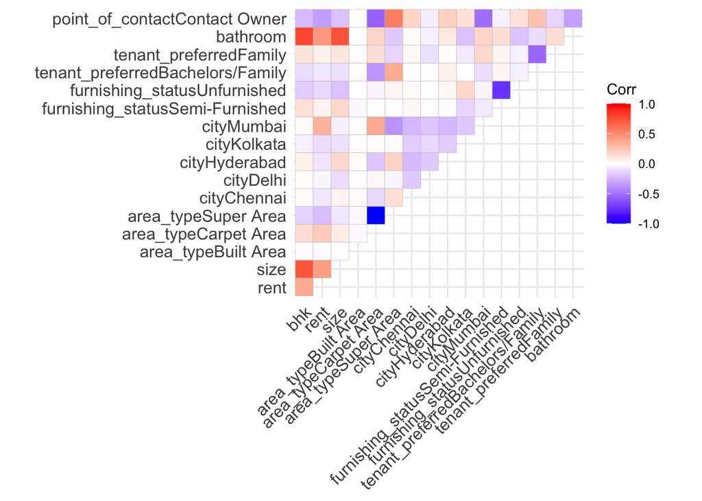

```r
model.matrix(~0+., data = rent_data) %>%
  cor(use="pairwise.complete.obs") %>%
  ggcorrplot(show.diag = F, type="upper")
```

### Analyzing the rent

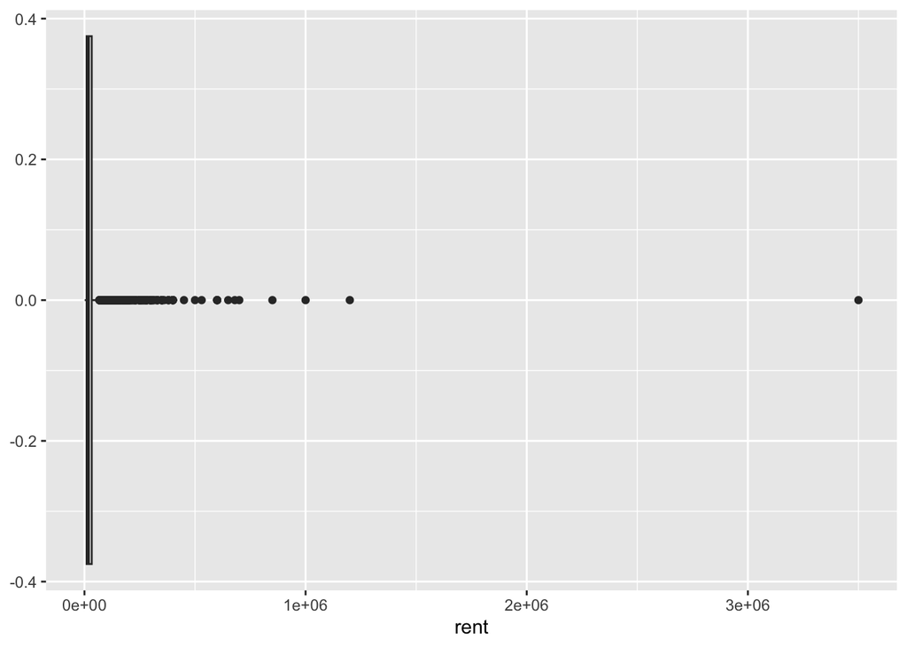

```r
ggplot(rent_data, aes(rent)) +
  geom_boxplot()
```

We could tell there are many outliers in Rent shown as horizontal dots, which affect us to build a valid predictive model, so I would like to drop few of them so that the distribution of Rent is not that skewed.

```r
rent_data %>%
  arrange(desc(rent)) %>%
  head(10)
```

```
##    bhk    rent size   area_type      city furnishing_status tenant_preferred
## 1    3 3500000 2500 Carpet Area Bangalore    Semi-Furnished        Bachelors
## 2    4 1200000 5000 Carpet Area    Mumbai    Semi-Furnished Bachelors/Family
## 3    4 1000000 3064 Carpet Area    Mumbai    Semi-Furnished           Family
## 4    4  850000 3200 Carpet Area    Mumbai         Furnished Bachelors/Family
## 5    4  700000 3200 Carpet Area    Mumbai         Furnished Bachelors/Family
## 6    4  680000 1962 Carpet Area    Mumbai    Semi-Furnished Bachelors/Family
## 7    5  650000 3000 Carpet Area    Mumbai    Semi-Furnished Bachelors/Family
## 8    4  600000 2500 Carpet Area    Mumbai    Semi-Furnished Bachelors/Family
## 9    5  600000 3200 Carpet Area    Mumbai    Semi-Furnished Bachelors/Family
## 10   5  600000 4500 Carpet Area    Mumbai         Furnished        Bachelors
##    bathroom point_of_contact
## 1         3    Contact Agent
## 2         4    Contact Agent
## 3         4    Contact Agent
## 4         4    Contact Agent
## 5         4    Contact Agent
## 6         5    Contact Agent
## 7         5    Contact Agent
## 8         4    Contact Agent
## 9         5    Contact Agent
## 10        5    Contact Agent
```

```r
df <- rent_data %>%
  filter(rent <= 600000)
```

Let’s see the distribution of Rent without extreme outliers.

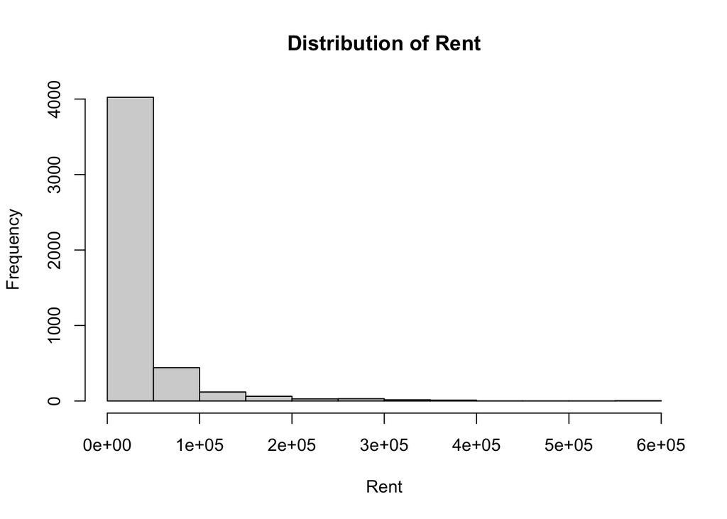

```r
hist(df$rent, xlab = "Rent", main = "Distribution of Rent")
```

```r
summary(df$rent)
```

```
##    Min. 1st Qu.  Median    Mean 3rd Qu.    Max.
##    1200   10000   16000   33240   32375  600000
```

Although it does not look good as well, we could not directly remove too many rows since they may be useful for prediction.

### Analyzing the BHK

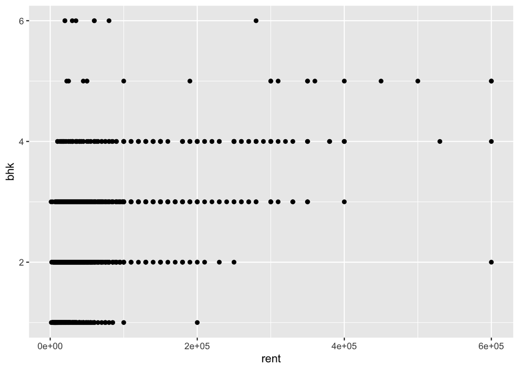

```r
ggplot(df, aes(x = rent, y = bhk)) + geom_point()
```

### Analyzing the Size

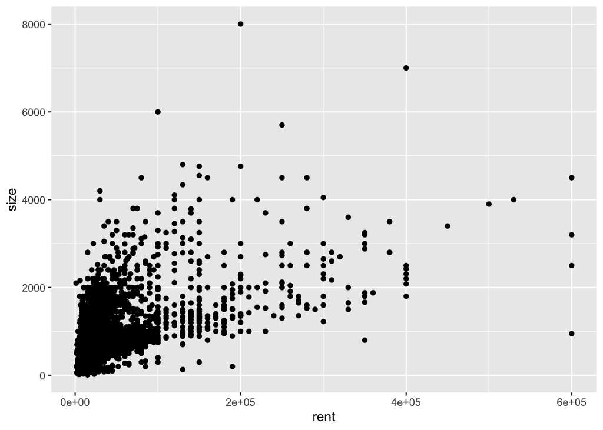

```r
ggplot(df, aes(x = rent, y = size)) + geom_point()
```

We are able to see a positive relationship between these two variables and this makes sense.

### Analyzing the Bathroom

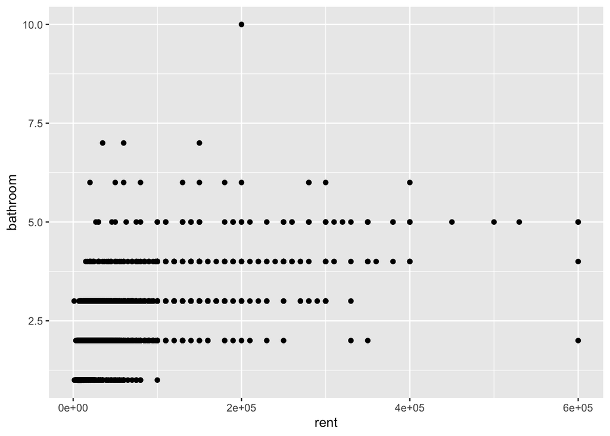

```r
ggplot(df, aes(x = rent, y = bathroom)) + geom_point()
```

We could also see a roughly positive relationship between *bathroom* and *rent*.

### Analyzing the categorical variables

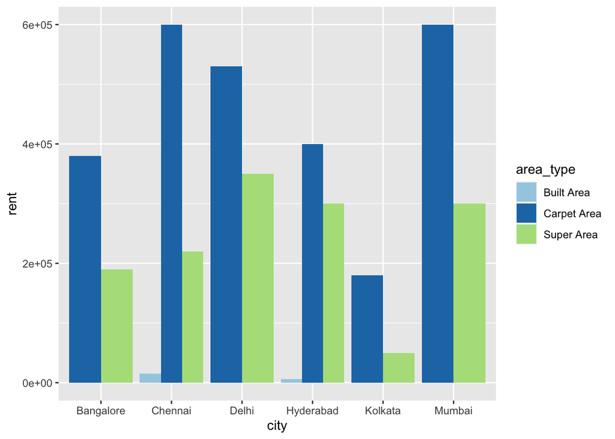

```r
ggplot(df, aes(x = city, y = rent, fill = area_type)) +
  geom_bar(stat = 'identity', position = position_dodge()) +
  scale_fill_brewer(palette = "Paired")
```

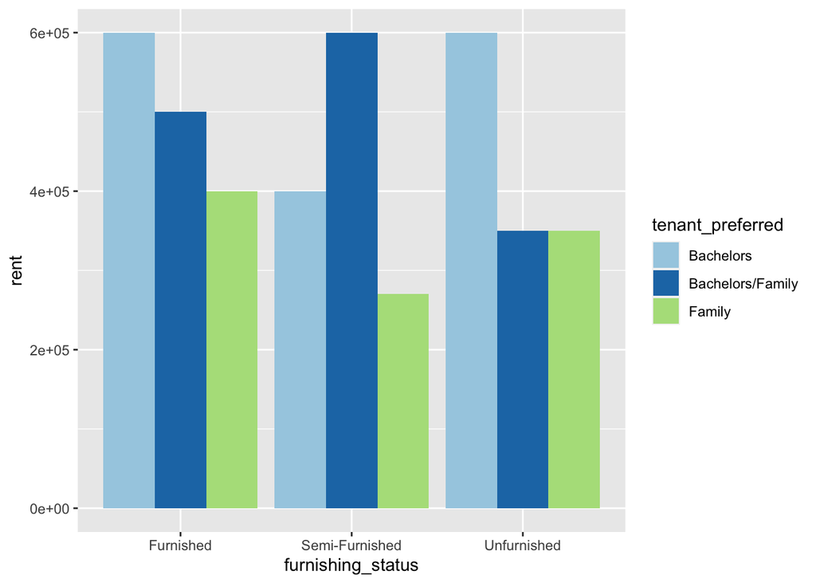

```r
ggplot(df, aes(x = furnishing_status, y = rent, fill = tenant_preferred)) +
  geom_bar(stat = 'identity', position = position_dodge()) +
  scale_fill_brewer(palette = "Paired")
```

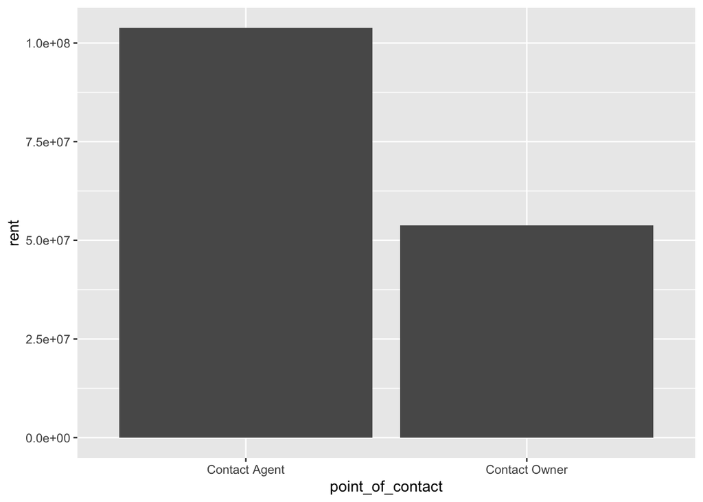

```r
ggplot(df, aes(x = point_of_contact, y = rent)) + geom_bar(stat = 'identity')
```

## Data Splitting and Cross-Validation

```r
set.seed(95)
rent_split <- initial_split(df, prop = 0.70, strata = rent)
rent_train <- training(rent_split)
rent_test <- testing(rent_split)
```

```r
rent_folds <- vfold_cv(rent_train, v = 10, strata = rent)
```

We are dividing the training set into 10 groups and using the first for validation and the remaining 9 groups for training. K-fold cross_validation randomly divide the data into k groups of equal sizes, holding out the first fold as the validation set, and the model is fit on the remaining k-1 folds to be training set.

## Create a Recipe

```r
rent_recipe <- recipe(rent ~ bhk + size + area_type + city + furnishing_status +
                        tenant_preferred + bathroom + point_of_contact, rent_train) %>%
  step_dummy(all_nominal_predictors()) %>%
  step_normalize(all_predictors()) %>%
  step_poly()
```

We build this model with rent be our response variables and other 8 variables be our predictors. We convert nominal data into one or more numeric binary model terms for the levels of the original data, enabling the model to predict based on these variables; and we normalize numeric data to have a standard deviation of one and a mean of zero.

## Model Fitting

### Linear Regression

```r
lm_model <- linear_reg() %>%
  set_engine("lm")

lm_wkflow <- workflow() %>%
  add_recipe(rent_recipe) %>%
  add_model(lm_model)

#fit the linear model to the training set:
lm_fit <- fit_resamples(lm_wkflow, resamples =  rent_folds, metrics = metric_set(rmse, rsq))

#In order to save time for knitting, we save each fitting result and load them in the next chunk.
write_rds(lm_fit, file = "lm_fit.rds")
```

```r
lm_fit <- read_rds("lm_fit.rds")

lm_fit %>% collect_metrics()
```

```
## # A tibble: 2 × 6
##   .metric .estimator      mean     n   std_err .config
##   <chr>   <chr>          <dbl> <int>     <dbl> <chr>
## 1 rmse    standard   32396.       10 1541.     Preprocessor1_Model1
## 2 rsq     standard       0.590    10    0.0179 Preprocessor1_Model1
```

The RMSE in linear regression model is extremely high and the RSQ is 0.59, means that the model is poor, so we are going to try another model later.

```r
lm <- collect_metrics(lm_fit) %>%
  arrange(desc(mean)) %>%
  filter(.metric == "rsq") %>%
  mutate(methods = "linear regression") %>%
  head(1)
#collect the main metric for later comparison
```

### Random Forest

```r
rf_model <- rand_forest(min_n = tune(), mtry = tune(), trees = tune(),
                        mode = "regression") %>%
  set_engine("ranger", importance = "impurity")

rf_workflow <- workflow() %>%
  add_model(rf_model) %>%
  add_recipe(rent_recipe)

param_grid1 <- grid_regular(mtry(range = c(1,8)), min_n(range = c(5, 20)),
                            trees(range = c(200,1000)), levels = 8)
#The last thing we need is the values of min_n, mtry, trees we are trying. This can be created using grid_regular(), which creates a grid of evenly spaced parameter values.
```

In this model, we tuned three parameters: ‘mtry’ represents that the number of variables randomly sampled as candidates at each split; ‘trees’ represents the number of decision trees to fit; ‘min_n’ represents the minimum number of data points in a node, which must be satisfied to further split the mode.

```r
tune_forest <- tune_grid(rf_workflow, resamples = rent_folds, grid = param_grid1)

write_rds(tune_forest, file = "rf_fit.rds")
```

We can view the model results:

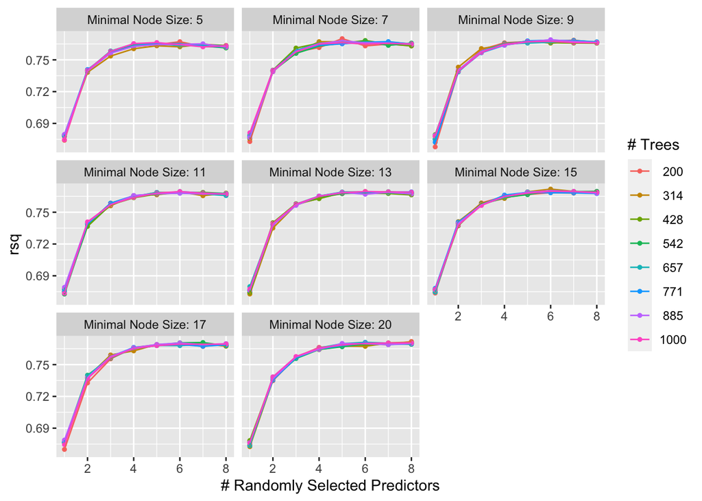

```r
rand_forest <- read_rds("rf_fit.rds")
autoplot(rand_forest, metric = "rsq")
```

In this plot, models with different number of trees perform nearly the same. But we could tell that model with 20 minimal node size and 6-8 predictors perform the best, reaching highest RSQ.

```r
rf <- collect_metrics(rand_forest) %>%
  arrange(desc(mean)) %>%
  filter(.metric == "rsq") %>%
  mutate(methods = "ranfom forest") %>% slice(1)
#collect the main matrics for later comparison
```

### Boosted Trees

```r
boost <- boost_tree(trees = tune()) %>%
  set_engine("xgboost") %>%
  set_mode("regression")

bt_wkflow <- workflow() %>%
  add_model(boost) %>%
  add_recipe(rent_recipe)

param_grid2 <- grid_regular(trees(range = c(10, 2000)), levels = 10)
```

```r
tune_boost <- tune_grid(bt_wkflow, resamples = rent_folds, grid = param_grid2)

write_rds(tune_boost, file = "bt_fit.rds")
```

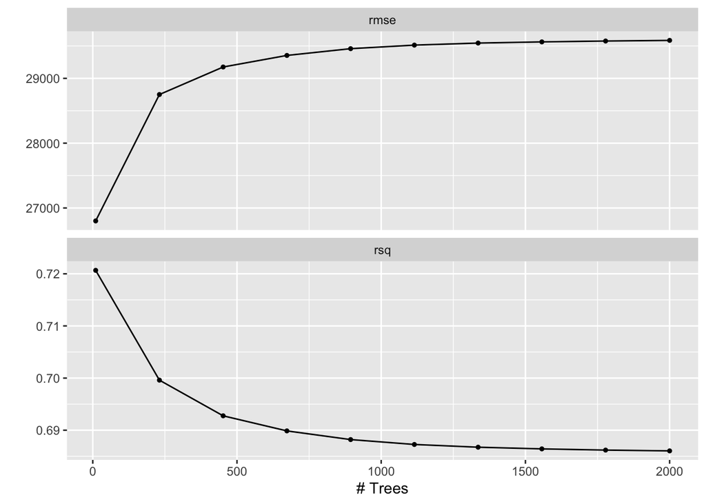

```r
boosted <- read_rds("bt_fit.rds")
autoplot(boosted)
```

The model performance decreases as the number of trees increases, showing higher RMSE and lower RSQ.

```r
bt <- collect_metrics(boosted) %>%
  arrange(desc(mean)) %>%
  filter(.metric == "rsq") %>%
  mutate(methods = "boosted tree") %>%
  head(1)
#collect the main matrics for later comparison
```

### K Nearest Neighbors

```r
knn_model <- nearest_neighbor(neighbors = tune(), mode = "regression") %>%
  set_engine("kknn")

knn_workflow <- workflow() %>%
  add_model(knn_model) %>%
  add_recipe(rent_recipe)

param_grid3 <- grid_regular(neighbors(range = c(2,10)), levels = 8)
```

```r
tune_knn <- tune_grid(knn_workflow, resamples = rent_folds, param_grid3)

write_rds(tune_knn, file = "knn_fit.rds")
```

[figure not shown]

```r
knn_fit <- read_rds("knn_fit.rds")
autoplot(knn_fit, metric = "rsq")
```

The model performance increases when the number of nearest neighbors increases.

```r
knn <- collect_metrics(knn_fit) %>%
  arrange(desc(mean)) %>%
  filter(.metric == "rsq") %>%
  mutate(methods = "KNN") %>%
  head(1)
knn
```

[output not shown]

## Assessing Model Performance

```r
models <- bind_rows(lm, rf, bt, knn) %>%
  select(methods, .metric, mean)
models
```

```
## # A tibble: 4 × 3
##   methods           .metric  mean
##   <chr>             <chr>   <dbl>
## 1 linear regression rsq     0.590
## 2 ranfom forest     rsq     0.772
## 3 boosted tree      rsq     0.721
## 4 KNN               rsq     0.743
```

After comparing, the random forest model has the highest RSQ = 0.7718723, which means it performs the best. So we could fit it to the testing set:

```r
best_model <- select_best(rand_forest, metric = "rmse")
#to find the best
final_wkflow <- finalize_workflow(rf_workflow, best_model)
#Now, this best model should be fit again, this time using the training data set.
finalfit <- fit(final_wkflow, rent_train)
rent_final <- predict(finalfit, rent_test)

df_metric <- metric_set(rsq)
rent_final %>%
  df_metric(truth = rent_test$rent, estimate = .pred)
```

```
## # A tibble: 1 × 3
##   .metric .estimator .estimate
##   <chr>   <chr>          <dbl>
## 1 rsq     standard       0.738
```

The model performs well with RSQ value of 0.7386576, which is relatively high. The RSQ on training set is 0.7718723, they differ and the RSQ of testing is lower because we fit the model with training data set. And although stratifying the data, the distribution of training and testing data set might be slightly different.

## Conclusion

In this project, I applied four models- linear regression, random forest, boosted tree, K nearest neighbors- to realize a regression problem about predicting rent based on different predictors including the number of bedrooms, hall, and kitchen, size in square feet, location, furnishing status, types of preferred tenants, number of bedrooms and point of contact; the random forest model performs the best and based on my results, we are supposed to use random forest model to predict or help to price corresponding rent according to different status of houses/apartments/flats. While the linear regression model performs poorly, the possible reason is that there are some correlation between predictors so that this is not a linear model.

I think that this is not a perfect predicting model because I used a large-scaled data of outcome variable, and the data is in extremely skewed distribution. Because of this kind of distribution, RMSE value in each value are significantly high, reaching to 30,000 and more. It is better to use a transformation algorithm to transform the responses to normal distribution, then fit new models and predict on it, which would make the RMSE lower and seems rational.

The above analysis is necessary for pricing new housing sources and it is important nowadays since people’s needs for leasing is increasing as time goes by. By refining this model, more business value might be generated.